# AYMEN ELLOUMI - TEST APPLICATION

### Applying for the Data Science INTERN Position

Hopefuly you'll appreciate my work and find it good enough. I'll sure be waiting for your feedback.

#### Let's Start with the Data

```python
# Common imports
import numpy as np
import pandas as pd
import os

# to make this notebook's output stable across runs
np.random.seed(42)

# To plot pretty figures
%matplotlib inline
import matplotlib
import matplotlib.pyplot as plt
```

```python
#Importing data
data = pd.read_csv('housing.csv', sep=';')
```

### Getting more comfortable with the data...

Let's take a look at top five rows using the df's head() method. As we notice there are 12 attributes and unnamed 0 seems like an index, I think it doesn't hurt keeping it

```python
data.head()
```

|  | Unnamed: 0 | price | lotsize | bedrooms | bathrms | stories | driveway | recroom | fullbase | gashw | airco | garagepl | prefarea |
| --- | --- | --- | --- | --- | --- | --- | --- | --- | --- | --- | --- | --- | --- |
| 0 | 1 | 42000.0 | 5850 | 3 | 1 | 2 | yes | no | yes | no | no | 1 | no |
| 1 | 2 | 38500.0 | 4000 | 2 | 1 | 1 | yes | no | no | no | no | 0 | no |
| 2 | 3 | 49500.0 | 3060 | 3 | 1 | 1 | yes | no | no | no | no | 0 | no |
| 3 | 4 | 60500.0 | 6650 | 3 | 1 | 2 | yes | yes | no | no | no | 0 | no |
| 4 | 5 | 61000.0 | 6360 | 2 | 1 | 1 | yes | no | no | no | no | 0 | no |

546 entries (instances), so that means we are dealing with a very small data by ML standards. (but it's just a test righ? :p ) The Attributes (price, bedrroms, bathrms, stories and garagepl) are numerics which is obvious, yet the attributes (recroom, fullbase, gashw, airco and prefarea) are of type object, so it could any kind of python object, but since I'm comfortable with this data and by the look of the top rows, Probably theses are categorical attributes (yes/no)

```python
data.info()
```

```
<class 'pandas.core.frame.DataFrame'>
RangeIndex: 546 entries, 0 to 545
Data columns (total 13 columns):
Unnamed: 0    546 non-null int64
price         546 non-null float64
lotsize       546 non-null int64
bedrooms      546 non-null int64
bathrms       546 non-null int64
stories       546 non-null int64
driveway      546 non-null object
recroom       546 non-null object
fullbase      546 non-null object
gashw         546 non-null object
airco         546 non-null object
garagepl      546 non-null int64
prefarea      546 non-null object
dtypes: float64(1), int64(6), object(6)
memory usage: 55.5+ KB
```

#### Stating the obvious about categorical attributes

It won't hurt confirming the categorical attributes theory, so I'll just go by fetching the categories that exists in each attribute, using the value_counts()

```python
data["driveway"].value_counts()
```

```
yes    469
no      77
Name: driveway, dtype: int64
```

```python
data["recroom"].value_counts()
```

```
no     449
yes     97
Name: recroom, dtype: int64
```

```python
data["fullbase"].value_counts()
```

```
no     355
yes    191
Name: fullbase, dtype: int64
```

```python
data["gashw"].value_counts()
```

```
no     521
yes     25
Name: gashw, dtype: int64
```

```python
data["airco"].value_counts()
```

```
no     373
yes    173
Name: airco, dtype: int64
```

```python
data["prefarea"].value_counts()
```

```
no     418
yes    128
Name: prefarea, dtype: int64
```

## Describing in deep

Let's take look at the summary of the numerical attributes. First let's drop the unnamed 0, we won't be needing it anyways.

#### Well :

count, mean, min and max are self explanotory. yet I still wonder who need 4 bathrooms in a single house x)

```python
data = data.drop(['Unnamed: 0'], axis=1)
data.describe()
```

|  | price | lotsize | bedrooms | bathrms | stories | garagepl |
| --- | --- | --- | --- | --- | --- | --- |
| count | 546.000000 | 546.000000 | 546.000000 | 546.000000 | 546.000000 | 546.000000 |
| mean | 68121.597070 | 5150.265568 | 2.965201 | 1.285714 | 1.807692 | 0.692308 |
| std | 26702.670926 | 2168.158725 | 0.737388 | 0.502158 | 0.868203 | 0.861307 |
| min | 25000.000000 | 1650.000000 | 1.000000 | 1.000000 | 1.000000 | 0.000000 |
| 25% | 49125.000000 | 3600.000000 | 2.000000 | 1.000000 | 1.000000 | 0.000000 |
| 50% | 62000.000000 | 4600.000000 | 3.000000 | 1.000000 | 2.000000 | 0.000000 |
| 75% | 82000.000000 | 6360.000000 | 3.000000 | 2.000000 | 2.000000 | 1.000000 |
| max | 190000.000000 | 16200.000000 | 6.000000 | 4.000000 | 4.000000 | 3.000000 |

### Let's plot, Shall we?

I'll be plotting the data in get another quick look of the kind of data I'm dealing with, Using histogram for each numerical attribute. Number of instancece by the value range.

```
array([[<matplotlib.axes._subplots.AxesSubplot object at 0x115cab320>,
      dtype=object)
```

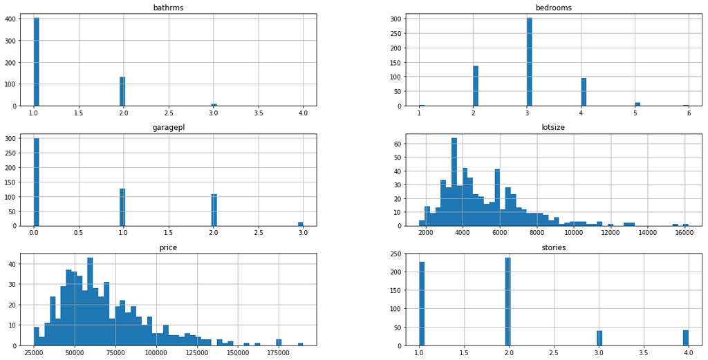

```python
data.hist(bins=50, figsize=(20,10))
```

#### Well :

The Price and Lotsize histograms are tail heavy, means that they extend o right of the median. which is not a good thing for ML algorithms to detect patters. A transformation may be needed.

## Oups! We forget about the Categorical Attributes

### Just kidding..

Transforming all the categorical attributes into quantitave so we can apply them to a ML algorithm later and get a bigger picture

```python
driveway = data['driveway']
data_driveway_transformed, driveway_categories = driveway.factorize()

recroom = data['recroom']
data_recroom_transformed, recroom_categories = recroom.factorize()

fullbase = data['fullbase']
data_fullbase_transformed, fullbase_categories = fullbase.factorize()

gashw = data['gashw']
data_gashw_transformed, gashw_categories = gashw.factorize()

airco = data['airco']
data_airco_transformed, airco_categories = airco.factorize()


prefarea = data['prefarea']
data_prefarea_transformed, prefareas_categories = prefarea.factorize()

driveway_categories
```

```
Index(['yes', 'no'], dtype='object')
```

### Before I start doing that, it is preferably that I do a testset.. why?

Well, at the moment, let's just say it's best pracctice to do that.

Since we don't have much data, I'll be splitting it into half testing set and the other for training. (normally 20% and 80%, but I'm just trying to adapt :p )

```python
# CREATE TRATN AND  TEST SET with a test_ration : 0.2 / 0.3 / 0.4 ....
def split_train_test(data, test_ratio):
    shuffled_indices = np.random.permutation(len(data))
    test_set_size = int(len(data) * test_ratio)
    test_indices = shuffled_indices[:test_set_size]
    train_indices = shuffled_indices[test_set_size:]
    return data.iloc[train_indices], data.iloc[test_indices]
```

```python
# 20% OF DATA WILL GO INTO TEST_SET
train_set, test_set = split_train_test(data, 0.5)
print(len(train_set), "train +", len(test_set), "test")
```

```
273 train + 273 test
```

```python
# WORK ON A COPY
data = train_set.copy()
```

```python
data.head()
```

|  | price | lotsize | bedrooms | bathrms | stories | driveway | recroom | fullbase | gashw | airco | garagepl | prefarea |
| --- | --- | --- | --- | --- | --- | --- | --- | --- | --- | --- | --- | --- |
| 36 | 61700.0 | 4032 | 2 | 1 | 1 | yes | no | yes | no | no | 0 | no |
| 139 | 43000.0 | 3750 | 3 | 1 | 2 | yes | no | no | no | no | 0 | no |
| 253 | 60000.0 | 4600 | 3 | 2 | 2 | yes | no | no | no | yes | 1 | no |
| 321 | 88500.0 | 6350 | 3 | 2 | 3 | yes | yes | no | no | yes | 0 | no |
| 59 | 30000.0 | 2400 | 3 | 1 | 2 | yes | no | no | no | no | 0 | no |

### Looking for Correlations

Since we're aiming for the price, let's check which attributes correlate with price. Obviously the the lot size of a property in square feet is important, but weird that the bathrooms number is beating the number of bedrooms which are insignificant almost comparing to the other attributes

```python
corr_matrix = data.corr()
corr_matrix["price"].sort_values(ascending=False)
```

```
price       1.000000
bathrms     0.511088
lotsize     0.494879
garagepl    0.436866
stories     0.386023
bedrooms    0.350389
Name: price, dtype: float64
```

```
array([[<matplotlib.axes._subplots.AxesSubplot object at 0x115fa4668>,
      dtype=object)
```

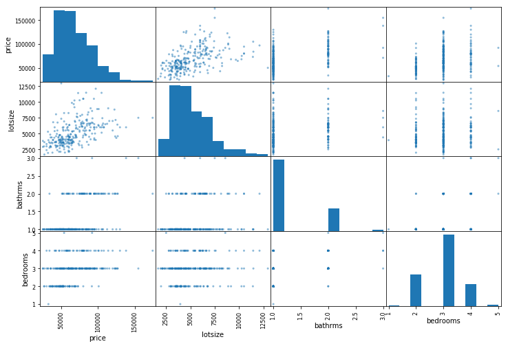

```python
# from pandas.tools.plotting
from pandas.plotting import scatter_matrix

attributes = ["price", "lotsize", "bathrms",
              "bedrooms"]
scatter_matrix(data[attributes], figsize=(12, 8))
```

This plot reveals a few things. The correlation is indeed strong, but not so very strong, as wec an yet see some dispersed points that we need to deal with in the future so our ML algorithm can learn from that too.

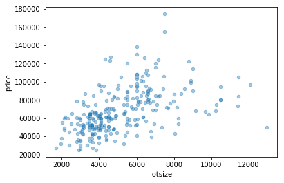

```python
data.plot(kind="scatter", x="lotsize", y="price",
             alpha=0.4)
```

### ADDING THE CAT DATA

HARDCORE WAY REPLACING Yes with 1 and no with 0 ;

```python
cleanup_nums = {"driveway":     {"yes": 1, "no": 0},
                "recroom":     {"yes": 1, "no": 0},
                "fullbase":     {"yes": 1, "no": 0},
                "gashw":     {"yes": 1, "no": 0},
                "airco":     {"yes": 1, "no": 0},
                "prefarea":     {"yes": 1, "no": 0},

               }
```

```python
data.replace(cleanup_nums, inplace=True)
data.head()
```

|  | price | lotsize | bedrooms | bathrms | stories | driveway | recroom | fullbase | gashw | airco | garagepl | prefarea |
| --- | --- | --- | --- | --- | --- | --- | --- | --- | --- | --- | --- | --- |
| 36 | 61700.0 | 4032 | 2 | 1 | 1 | 1 | 0 | 1 | 0 | 0 | 0 | 0 |
| 139 | 43000.0 | 3750 | 3 | 1 | 2 | 1 | 0 | 0 | 0 | 0 | 0 | 0 |
| 253 | 60000.0 | 4600 | 3 | 2 | 2 | 1 | 0 | 0 | 0 | 1 | 1 | 0 |
| 321 | 88500.0 | 6350 | 3 | 2 | 3 | 1 | 1 | 0 | 0 | 1 | 0 | 0 |
| 59 | 30000.0 | 2400 | 3 | 1 | 2 | 1 | 0 | 0 | 0 | 0 | 0 | 0 |

### Some Viz Fun

#### Can we get something Interesting ?

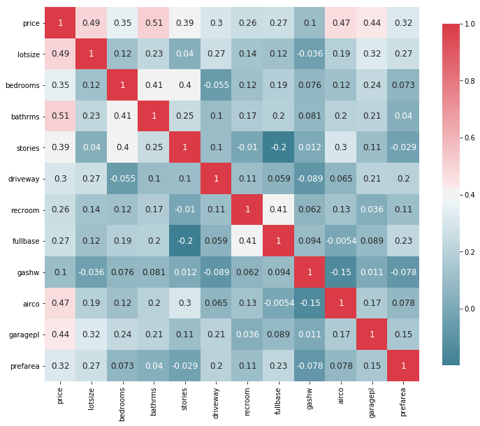

```python
def plot_correlation_map( df ):
    corr = df.corr()
    _ , ax = plt.subplots( figsize =( 12 , 10 ) )
    cmap = sns.diverging_palette( 220 , 10 , as_cmap = True )
    _ = sns.heatmap(
        corr,
        cmap = cmap,
        square=True,
        cbar_kws={ 'shrink' : .9 },
        ax=ax,
        annot = True,
        annot_kws = { 'fontsize' : 12 }
    )

plot_correlation_map( data )
```

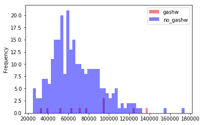

```python
gashw = data[data["gashw"] == 1]
no_gashw = data[data["gashw"] == 0]
gashw["price"].plot.hist(alpha=0.5,color='red',bins=50)
no_gashw["price"].plot.hist(alpha=0.5,color='blue',bins=50)
plt.legend(['gashw','no_gashw'])
plt.show()
```

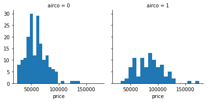

```python
%matplotlib inline
import seaborn as sns

g = sns.FacetGrid(data, col='airco')
g.map(plt.hist, 'price', bins=20)
```

I'm interested with driveways

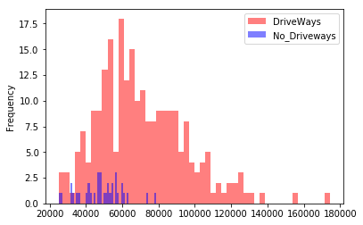

```python
driveways = data[data["driveway"] == 1]
no_driveways = data[data["driveway"] == 0]
driveways["price"].plot.hist(alpha=0.5,color='red',bins=50)
no_driveways["price"].plot.hist(alpha=0.5,color='blue',bins=50)
plt.legend(['DriveWays','No_Driveways'])
plt.show()
```

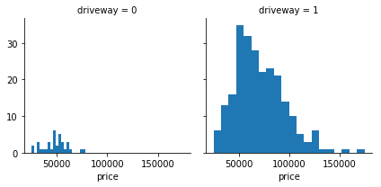

```python
g = sns.FacetGrid(data, col='driveway')
g.map(plt.hist, 'price', bins=20)
```

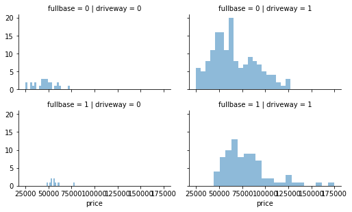

```python
grid = sns.FacetGrid(data, col='driveway', row='fullbase', size=2.2, aspect=1.6)
grid.map(plt.hist, 'price', alpha=.5, bins=20)
grid.add_legend();
```

### Some Fun with Distribution Viz

```python
def plot_distribution( df , var , target , **kwargs ):
    row = kwargs.get( 'row' , None )
    col = kwargs.get( 'col' , None )
    facet = sns.FacetGrid( df , hue=target , aspect=4 , row = row , col = col )
    facet.map( sns.kdeplot , var , shade= True )
    facet.set( xlim=( 0 , df[ var ].max() ) )
    facet.add_legend()
```

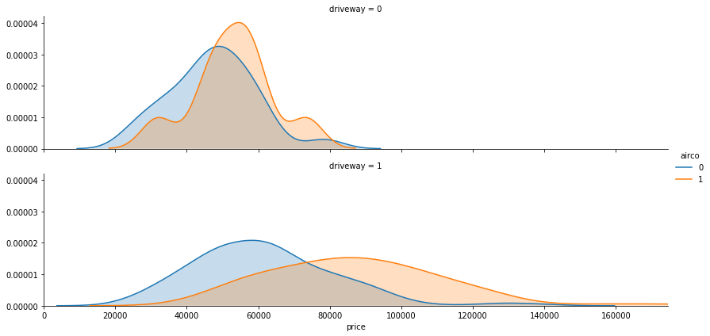

```python
plot_distribution( data , var = 'price' , target = 'airco' , row = 'driveway' )
```

## Time to Prepare My Data for some ML Algorithms.

First I'll try to scale the lotsize so it can be normally distributed

```python
# Other Libraries
import warnings
warnings.filterwarnings("ignore")
import plotly
from plotly import tools
import plotly.plotly as py
import plotly.figure_factory as ff
import plotly.graph_objs as go
from plotly.offline import download_plotlyjs, init_notebook_mode, plot, iplot
init_notebook_mode(connected=True)
```

```python
#Scaling lotsize
lotsize_dist = data["lotsize"].values
log_lotsize = np.log(data["lotsize"])

trace0 = go.Histogram(
    x=lotsize_dist,
    histnorm='probability',
    name="LotSize Distribution",
    marker = dict(
        color = '#FA5858',
    )
)
trace1 = go.Histogram(
    x=log_lotsize,
    histnorm='probability',
    name="LotSize Distribution using Log",
    marker = dict(
        color = '#58FA82',
    )
)

fig = tools.make_subplots(rows=2, cols=1,
                          subplot_titles=('Lotsize Distribution','Log Lotsize Distribution'),
                         print_grid=False)

fig.append_trace(trace0, 1, 1)
fig.append_trace(trace1, 2, 1)


fig['layout'].update(showlegend=True, title='Lotsize Distribution', bargap=0.05)
plotly.offline.iplot(fig, filename='custom-sized-subplot-with-subplot-titles')
```

[interactive chart not shown]

## It's Modeling Time !

Since, I'm dealing with much quantitative data, and I'll need to predict the price not categories. This is definteley a Regression Problem.

```python
data = train_set.drop("price", axis=1) # drop labels for training set
data_price = train_set["price"].copy()
labels_to_take= data[['lotsize', 'bedrooms', 'bathrms', 'stories','garagepl']]

from sklearn.model_selection import train_test_split
train_X, test_X, train_y, test_y = train_test_split(
    labels_to_take, data_price, test_size=0.2)
```

```python
from sklearn.linear_model import LinearRegression

lin_reg = LinearRegression()
lin_reg.fit(labels_to_take, data_price)
Yhat=lin_reg.predict(labels_to_take)
```

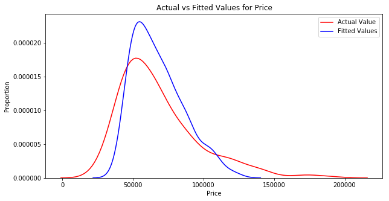

```python
width = 10
height = 5
plt.figure(figsize=(width, height))

ax1 = sns.distplot(test_set['price'], hist=False, color="r", label="Actual Value")
sns.distplot(Yhat, hist=False, color="b", label="Fitted Values" , ax=ax1)

plt.title('Actual vs Fitted Values for Price')
plt.xlabel('Price')
plt.ylabel('Proportion')

plt.show()
plt.close()
```

### Polynomial regression

```python
from sklearn.preprocessing import PolynomialFeatures

pr=PolynomialFeatures(degree=2)
Z_pr=pr.fit_transform(X)

lm = LinearRegression()

lm.fit(Z_pr,Y)
Yhat_poly=lm.predict(Z_pr)
```

### Pipelines

```python
from sklearn.pipeline import Pipeline
from sklearn.preprocessing import StandardScaler

Input=[('scale',StandardScaler()),('polynomial', PolynomialFeatures(include_bias=False)),('model',LinearRegression())]

pipe=Pipeline(Input)
pipe.fit(labels_to_take,data_price)
ypipe=pipe.predict(labels_to_take)
```

### Metrics R² MSE

```python
from sklearn.metrics import mean_squared_error
from sklearn.metrics import r2_score

print(r2_score(data_price, ypipe))
print(mean_squared_error(data_price, ypipe))
```

```
0.6159714113306779
229549072.96874216
```

### Just for the sake of it SVM

```python
from sklearn.svm import SVR
from sklearn.metrics import accuracy_score


svm_reg = SVR(kernel="linear")
svm_reg.fit(train_X, train_y)
data_predictions = svm_reg.predict(train_X)
svm_mse = mean_squared_error(train_y, data_predictions)
svm_rmse = np.sqrt(svm_mse)

svm_rmse
```

```
21462.697446826434
```

At The end, from a first sight of the problem, I would say that this a lienar regression problem. If I would do this research in more deep way, I would add my other variable into the equation and dive into more details.

## Conclusion

We can use this kind of solutions to predict house prices in the futur, and that would be very helpful for insurances. Also, it helps in marketing. A System like that will determine wether it is worth investing in a given area or not, if it is made righ, it will directly affects revenue.

I could have worked on converting the prices into categories (cheap, medium, expensive) and it would have helped, using categories instead of the prices, and I wouldn't be worrying much about the exact price and then it would've been a classification problem.

I know for sure my models aren't perfect and they need tuning and better pipelines, and I can work on that in the futur.

Hopefully you had fun reviewing my work and you'll be able to give me a chance to get better in your prestigious company.

Sincerely yours,

Aymen ELLOUMI